# DAPR2 09 bootstrapping demo EE

```r
library(tidyverse)

theme_set(theme_bw())
theme_update(
  strip.background = element_blank()
)
```

# v2

The main sample:

```r
population <- 1:100

# set the seed for the random number generator, so the random sample
# is the same every time
set.seed(2)

# draw the sample and sort in ascending order.
size_main_sample <- 10
main_sample <- sort(sample(population, size = size_main_sample))

for(i in 1:size_main_sample){
  message(main_sample[i])
}
```

```r
matrix(main_sample, ncol = 5, byrow=T)
```

```
     [,1] [,2] [,3] [,4] [,5]
[1,]    6    8   17   32   70
[2,]   76   79   81   85   93
```

What’s the average value, the mean, of the main sample?

```r
mean(main_sample)
```

```
[1] 54.7
```

If we drew many main samples from the population and repeatedly found their mean, then we would have a sense of the variability in the population.

In a simulated world like this, we can. But in real life, it’s not practical.

BUT: we *can* get a sense of the variability in our main sample by repeatedly drawing samples from *it* and finding *their* means.

**The variability in those means is our best guess about the variability in the population.**

## Bootstrapped samples

Export settings:

- CSV
- tick “Download all fields”
- select “Export labels”

Read in CSV data downloaded from Qualtrics.

```r
DATAFILE <- "DAPR2 09 Bootstrapping_10 September 2026_10.02.csv"

# source: https://stackoverflow.com/a/50314806
headers      <- read_csv(DATAFILE, col_names = FALSE, n_max = 1)
df           <- read_csv(DATAFILE, skip = 3, col_names = FALSE)
colnames(df) <- headers

nrow(df)
```

```
[1] 11
```

Wrangle into tidy (tall) format.

```r
df_tall <- df |>
  select(ResponseId, starts_with('Q')) |>
  pivot_longer(cols = starts_with('Q'),names_to = 'q', values_to = 'sampled_value')
head(df_tall)
```

| ResponseId | q | sampled_value |
| --- | --- | --- |
| R_8dRdM63kvu8RStT | Q1 | 70 |
| R_8dRdM63kvu8RStT | Q2 | 76 |
| R_8dRdM63kvu8RStT | Q3 | 8 |
| R_8dRdM63kvu8RStT | Q4 | 81 |
| R_8dRdM63kvu8RStT | Q5 | 70 |
| R_8dRdM63kvu8RStT | Q6 | 79 |

All of the samples chosen, plotted as continuous.

```r
df_tall |>
  ggplot(aes(x = sampled_value, fill = ResponseId)) +
  geom_histogram(binwidth = 1) +
  scale_x_continuous(limits = c(0, 100), breaks = seq(0, 100, by=10)) +
  theme(
    legend.position = 'none'
  ) +
  NULL
```

[output not shown]

All the samples chosen, shown as discrete (better):

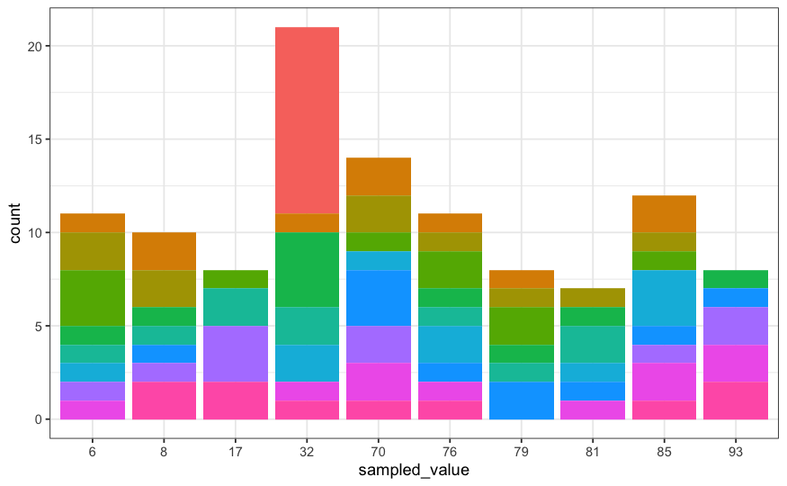

```r
df_tall |>
  mutate(sampled_value = factor(sampled_value)) |>
  ggplot(aes(x = sampled_value, fill = ResponseId)) +
  geom_bar() +
  theme(
    legend.position = 'none'
  ) +
  NULL
```

Look at a few individual bootstrapped samples.

```r
# compute how many different options each ppt chose
n_types_df <- df_tall |>
  group_by(ResponseId) |>
  count(sampled_value) |>
  count(ResponseId) |>
  arrange(n) |>
  ungroup()

# set the number of plots to show at each end
n_to_plot <- 3
```

Bootstrapped samples with the narrowest spread across choices:

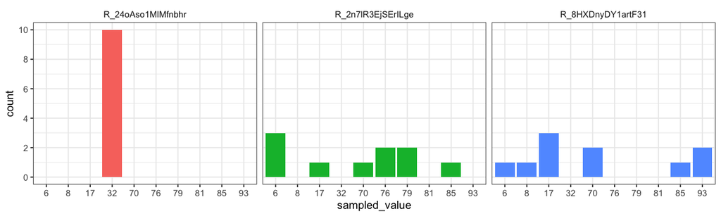

```r
ppts_narrow <- n_types_df |>
  slice_head(n = n_to_plot) |>
  pull(ResponseId)

df_tall |>
  mutate(sampled_value = factor(sampled_value)) |>
  filter(ResponseId %in% ppts_narrow) |>
  ggplot(aes(x = sampled_value, fill = ResponseId))+#, colour = ResponseId)) +
  geom_bar() +
  facet_wrap(~ ResponseId) +
  theme(legend.position = 'none') +
  scale_y_continuous(limits = c(0, 10), breaks = seq(0, 10, by = 2)) +
  scale_x_discrete(drop = FALSE)
```

Bootstrapped samples with the broadest spread across choices:

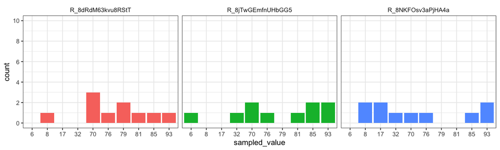

```r
ppts_broad <- n_types_df |>
  slice_tail(n = n_to_plot) |>
  pull(ResponseId)

df_tall |>
  mutate(sampled_value = factor(sampled_value)) |>
  filter(ResponseId %in% ppts_broad) |>
  ggplot(aes(x = sampled_value, fill = ResponseId))+#, colour = ResponseId)) +
  geom_bar() +
  facet_wrap(~ ResponseId) +
  theme(legend.position = 'none') +
  scale_y_continuous(limits = c(0, 10), breaks = seq(0, 10, by = 2)) +
  scale_x_discrete(drop = FALSE)
```

## Making the sampling distribution

Put all the sample means together. By combining the sample means, we create the **sampling distribution of sample means**.

```r
sampling_distrib <- df_tall |>
  group_by(ResponseId) |>
  summarise(sample_mean = mean(sampled_value))

sampling_distrib
```

| ResponseId | sample_mean |
| --- | --- |
| R_24oAso1MlMfnbhr | 32.0 |
| R_2flQx4VJU9orTYB | 51.9 |
| R_2gj8zbbULTN16oS | 48.9 |
| R_2n7lR3EjSErILge | 50.0 |
| R_2vQvrVQuepnNaSd | 47.1 |
| R_82LPqaQVWe8hHls | 42.9 |
| R_8HXDnyDY1artF31 | 47.6 |
| R_8NKFOsv3aPjHA4a | 49.9 |
| R_8coCY6kWmtOhrUt | 62.8 |
| R_8dRdM63kvu8RStT | 71.1 |

[output cut: 1 more lines]

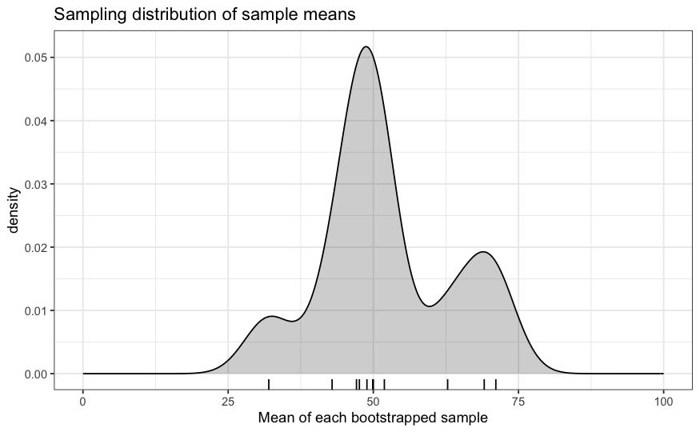

```r
p_samp_dist_dens <- sampling_distrib |>
  ggplot(aes(x = sample_mean)) +
  geom_density(fill = 'black', colour = 'black', alpha = 0.2) +
  geom_rug(colour = 'black') +
  labs(
    title = 'Sampling distribution of sample means',
    x = 'Mean of each bootstrapped sample'
  ) +
  xlim(0, 100)

p_samp_dist_dens
```

## Mean of sampling distribution

What is the mean of our sampling distribution of means?

```r
samp_distrib_mean <- mean( sampling_distrib$sample_mean )
samp_distrib_mean
```

```
[1] 52.1
```

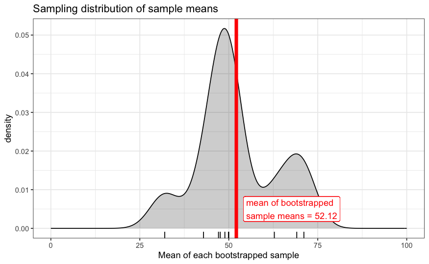

```r
p_samp_dist_dens +
  geom_vline(xintercept = samp_distrib_mean, linewidth = 2, colour = 'red') +
  geom_label(x = samp_distrib_mean+2, y = 0.005, colour = 'red', label = paste('mean of bootstrapped\nsample means =', round(samp_distrib_mean, 2)), hjust = 0)
```

Probably pretty close to the mean of our main sample:

```r
mean(main_sample)
```

```
[1] 54.7
```

```r
population
```

```
  [1]   1   2   3   4   5   6   7   8   9  10  11  12  13  14  15  16  17  18  19  20  21  22  23  24  25  26
 [27]  27  28  29  30  31  32  33  34  35  36  37  38  39  40  41  42  43  44  45  46  47  48  49  50  51  52
 [53]  53  54  55  56  57  58  59  60  61  62  63  64  65  66  67  68  69  70  71  72  73  74  75  76  77  78
 [79]  79  80  81  82  83  84  85  86  87  88  89  90  91  92  93  94  95  96  97  98  99 100
```

```r
mean(population)
```

```
[1] 50.5
```

If we draw the main sample at random from the population, then it’s as representative as we can possibly make it.

But bootstrapping only represents the population as well as the main sample does.

In other words, bootstrapping assumes that we have an accurate representative sample of the population. (And, chances are, we do.)

## The REALLY useful thing: Standard deviation of sampling distribution

What is the standard deviation of our sampling distribution?

```r
samp_distrib_sd <- sd( sampling_distrib$sample_mean )
samp_distrib_sd
```

```
[1] 11.5
```

Why is this number useful?

We use the **standard deviation of the sampling distribution** to represent the **standard error of the mean** in situations where the formula for the standard error can’t be used (e.g., because the assumptions about errors are not met.)

## 95% confidence interval based on sampling distribution

```r
quantile(sampling_distrib$sample_mean)
```

[output not shown]

```r
quantile(
  sampling_distrib$sample_mean,
  probs = c(0.025, 0.975)
)
```

[output not shown]